# sigexUI-overview

4/19/2022

```
## i Loading sigexUI
```

```
## i Loading sigex
```

## Disclaimer

This article is released to inform interested parties of ongoing research and to encourage discussion of work in progress. Any views expressed are those of the authors and not those of the U.S. Census Bureau.

## Why?

Following feedback from JSS and other users we aim to make `sigex` fit more seamlessly into the R ecosystem.

- User friendly defaults
- Error/wanrining checks
- Esstablished R function support
  - `residuals()`
  - `summary()`
  - `print()`

Want to “future proof” development of future add-ons.

- Don’t make classes or helper functions too rigid
- Think about the high level structures of multivariate unobserved component models

## Class system in R

R has a three-class system

- S3
- S4
- Reference Class

S3 Class

- S3 is the simplest yet the most popular
- lacks formal definition and structure
- An object of this type can be created by just adding an attribute to it
  - we will see this on the next slide with Arima class

S4 Class

- objects have a proper definition
- gives proper structure to its objects
- **We will be implimenting S4 classes in SigexUI**

## Example: fitting ARIMA model

We have all fit an ARIMA model to the AirPassengers Series.

```r
fit <- arima(AirPassengers, order = c(1, 0, 0))
class(fit)
```

```
## [1] "Arima"
```

## Example: fitting ARIMA model

The R ecosystem and its users is now familiar with the concepts of `fit` being the output of a model and with that comes ceritain expectations about how it should behave. For example,

```r
coef(fit)
##        ar1  intercept
##   0.964632 278.464942
```

```r
AIC(fit)
## [1] 1428.179
```

```r
logLik(fit)
## 'log Lik.' -711.0897 (df=3)
```

```r
predict(fit, n.ahead = 2)
## $pred
##           Jan      Feb
## 1961 426.5698 421.3316
##
## $se
##           Jan      Feb
## 1961 33.44577 46.47055
```

## Example: fitting ARIMA model

How does this happen?

First look at what is returned by the `arima()` function

```r
    structure(list(coef = coef, sigma2 = sigma2, var.coef = var, mask = mask,
           loglik = -0.5 * value, aic = aic, arma = arma,
           residuals = resid, call = match.call(), series = series,
           code = res$convergence, n.cond = ncond, nobs = n.used,
           model = mod),
          class = "Arima")
```

```r
str(fit)
```

```
## List of 14
##  $ coef     : Named num [1:2] 0.965 278.465
##   ..- attr(*, "names")= chr [1:2] "ar1" "intercept"
##  $ sigma2   : num 1119
##  $ var.coef : num [1:2, 1:2] 4.56e-04 -1.23e-02 -1.23e-02 4.50e+03
##   ..- attr(*, "dimnames")=List of 2
##   .. ..$ : chr [1:2] "ar1" "intercept"
##   .. ..$ : chr [1:2] "ar1" "intercept"
##  $ mask     : logi [1:2] TRUE TRUE
##  $ loglik   : num -711
##  $ aic      : num 1428
##  $ arma     : int [1:7] 1 0 0 0 12 0 0
##  $ residuals: Time-Series [1:144] from 1949 to 1961: -43.88 0.112 8.325 -8.18 -13.286 ...
##  $ call     : language arima(x = AirPassengers, order = c(1, 0, 0))
##  $ series   : chr "AirPassengers"
##  $ code     : int 0
##  $ n.cond   : int 0
##  $ nobs     : int 144
##  $ model    :List of 10
##   ..$ phi  : num 0.965
##   ..$ theta: num(0)
##   ..$ Delta: num(0)
##   ..$ Z    : num 1
##   ..$ a    : num 154
##   ..$ P    : num [1, 1] 0
##   ..$ T    : num [1, 1] 0.965
##   ..$ V    : num [1, 1] 1
##   ..$ h    : num 0
##   ..$ Pn   : num [1, 1] 1
##  - attr(*, "class")= chr "Arima"
```

## Example: fitting ARIMA model

Let’s look at the source code for *arima*

https://github.com/SurajGupta/r-source/blob/master/src/library/stats/R/arima.R

method dispatch for class *Arima* starts at line 373.

## Some S4 Definitions

- **Classes** user-defined data types, blueprint for individual objects, attributes and methods.
  - Has 3 key properties
    1. name: an alpha-numeric string that identifies the class
    2. representation/slots: a list of attributes, giving their names and classes
    3. contains: character vector of classes that it inherits from
- **Object** instances of a class created with specifically defined data. Objects can correspond to real-world objects or an abstract entity.
- **Generic Function** Function that dispatches to a method depending on the input class
- **Methods** Function that acts upon specific input class

```r
mean(1:10)
## [1] 5.5
mean(nycflights13::flights$time_hour)
## [1] "2013-07-03 05:22:54 EDT"
```

## Methods and Generic functions for different classes

All methods that belong to the generic function `mean()`

```r
methods("mean")
```

```
## [1] mean.Date        mean.default     mean.difftime    mean.POSIXct
## [5] mean.POSIXlt     mean.quosure*    mean.vctrs_vctr*
## see '?methods' for accessing help and source code
```

List all generic functions that have a method for `ts` class

```r
methods(class = "ts")
```

```
##  [1] [               [<-             aggregate       as.data.frame
##  [5] cbind           coerce          cycle           diff
##  [9] diffinv         initialize      kernapply       lines
## [13] Math            Math2           monthplot       na.omit
## [17] Ops             plot            print           setRegComponent
## [21] show            slotsFromS3     t               time
## [25] window          window<-
## see '?methods' for accessing help and source code
```

## Structure of sigexUI: Classes

We created a class for the following objects:

1. Parameters
2. Models
3. Time Series Components
4. Model Fit

## SigexParam

A SigexParam has three things:

1. A list of K GCDs
2. The time series parameters whose exact form depends on the class of this latent process
3. Regression parameters

```r
#' @export
setClass("SigexParam",
    slots = c(
        N = "numeric", # Used to be integer but floating pt arithmetic issues
        gcds = "list",
        ts_params = "list",
        reg_param = "numeric"
    ),#
    prototype = list(
        N = NA_integer_,
    #   gcd_list = list(),
    #   ts_param_list = NA_real_,
        reg_param = NA_real_
    )
)
```

## Additional param sub-classes

```r
#' @export
setClass("SigexParamARMA",
    contains = "SigexParamTS",
    slots = c(ar = "matrix", ma = "matrix"),
    prototype = list(model_class = "ARMA")
)

#' @export
setClass("SigexParamVARMA",
    contains = "SigexParamTS",
    slots = c(ar = "array", ma = "array"),
    prototype = list(model_class = "VARMA")
)
```

## Model class

The components slot is a list of time series components which themselves are a class. This allows flexibility when printing, error checking, etc each individial component.

```r
#' @export
setClass("SigexModel",
    slots = c(
        N = "integer",
        mdl = "list",
        components = "list"
    ),
    prototype = list(
        N = NA_integer_,
        mdl = NULL,
        components = list()
    )
)
```

## Model component abstract base class

```r
# This is an abstract base class
#' @export
setClass("SigexModelComponent",
    slots = c(
        model_class = "character",
        delta = "numeric",
        epithet = "character"
    ),
    prototype = list(
        model_class = "NULL",
        delta = NULL,
        epithet = "NULL"
    )
)
```

## Model component classes

```r
# This class inherits from SigexModelComponent
#' @export
setClass("SigexModelComponentVARMA",
    contains = "SigexModelComponent",
    slots = c(
        p = "numeric",
        q = "numeric"
    ),
    prototype = list(
        model_class = "varma"
    )
)


# This class inherits from SigexModelComponent
#' @export
setClass("SigexModelComponentARMA",
         contains = "SigexModelComponent",
         slots = c(
            p = "numeric",
            q = "numeric"
         ),
         prototype = list(
            model_class = "varma"
         )
)
```

## Old way of setting up model

```r
# Set up a model
mdl = NULL
mdl = sigex.add(mdl = mdl,
    vrank = seq(1,N),
    class = "arma",
    order = c(2, 3),
    bounds = NULL,
    name = "process1",
    delta = c(1,-1) )
mdl = sigex.add(mdl = mdl,
                vrank = seq(1,N),
                class = "arma",
                order = c(4, 5),
                bounds = NULL,
                name = "process2",
                delta = c(1,-1) )
mdl = sigex.add(mdl = mdl,
                vrank = seq(1,N),
                class = "varma",
                order = c(6, 7),
                bounds = NULL,
                name = "process3",
                delta = c(1,-1) )
mdl = sigex.meaninit(mdl = mdl, data.ts = data.ts, d = 0)
```

## SigexUI way of setting up model

```r
model <- SigexModel(N) %>%
    addComponent(SigexModelComponentARMA(p = 2,
                                         q = 3,
                                         epithet = "comp1",
                                         delta = c(1, -1))) %>%
    addComponent(SigexModelComponentARMA(p = 4,
                                         q = 5,
                                         epithet = "comp2",
                                         delta = c(1, -1))) %>%
    addComponent(SigexModelComponentVARMA(p = 6,
                                         q = 7,
                                         epithet = "comp3",
                                         delta = c(1, -1))) %>%
    setRegComponent(data.ts, d = 0)
```

## Compare print

```r
model
```

```
## SigexModel for 2-dimensional series with 3 component(s)
## 1) SigexModelComponent: model_class = arma, epithet = "comp1", delta = (1,-1)
## 2) SigexModelComponent: model_class = arma, epithet = "comp2", delta = (1,-1)
## 3) SigexModelComponent: model_class = varma, epithet = "comp3", delta = (1,-1)
## Regression model is set
```

```r
mdl
```

```
## $ranks
## $ranks[[1]]
## [1] 1 2
##
## $ranks[[2]]
## [1] 1 2
##
## $ranks[[3]]
## [1] 1 2
##
##
## $type
## $type[[1]]
## $type[[1]][[1]]
## [1] "arma"
##
## $type[[1]][[2]]
## [1] 2 3
##
## $type[[1]][[3]]
## NULL
##
## $type[[1]][[4]]
## [1] "process1"
##
##
## $type[[2]]
## $type[[2]][[1]]
## [1] "arma"
##
## $type[[2]][[2]]
## [1] 4 5
##
## $type[[2]][[3]]
## NULL
##
## $type[[2]][[4]]
## [1] "process2"
##
##
```

[output cut: 75 more lines]

```
## 2006 169 170 171 172 173 174 175 176 177 178 179 180
## 2007 181 182 183 184 185 186 187 188 189 190 191 192
## 2008 193 194 195 196 197 198 199 200 201 202 203 204
## 2009 205 206 207 208 209 210 211 212 213 214 215 216
## 2010 217 218 219 220 221 222 223 224 225 226 227 228
## 2011 229 230 231 232 233 234 235 236 237 238 239 240
## 2012 241 242 243 244 245 246 247 248 249 250 251 252
## 2013 253 254 255 256 257 258 259 260 261 262 263 264
## 2014 265 266 267 268 269 270 271 272 273 274 275 276
## 2015 277 278 279 280 281 282 283 284 285 286 287 288
## 2016 289 290 291 292 293 294 295 296 297 298 299 300
## 2017 301 302 303 304 305 306 307 308 309 310 311 312
## 2018 313 314 315 316 317 318 319 320 321 322 323 324
## 2019 325 326 327 328 329 330 331 332 333 334 335 336
## 2020 337 338 339 340 341
```

## Old way of setting up parameters

```r
par = sigex.default(mdl = mdl, data.ts = data.ts, constraint = NULL)
print(par)
```

```
## [[1]]
## [[1]][[1]]
##      [,1] [,2]
## [1,]    1    0
## [2,]    0    1
##
## [[1]][[2]]
##      [,1] [,2]
## [1,]    1    0
## [2,]    0    1
##
## [[1]][[3]]
##      [,1] [,2]
## [1,]    1    0
## [2,]    0    1
##
##
## [[2]]
## [[2]][[1]]
## [1] 0 0
##
## [[2]][[2]]
## [1] 0 0
##
## [[2]][[3]]
## [1] 0 0
##
##
## [[3]]
## [[3]][[1]]
##      [,1] [,2] [,3] [,4] [,5]
## [1,]    0    0    0    0    0
## [2,]    0    0    0    0    0
##
## [[3]][[2]]
##      [,1] [,2] [,3] [,4] [,5] [,6] [,7] [,8] [,9]
## [1,]    0    0    0    0    0    0    0    0    0
## [2,]    0    0    0    0    0    0    0    0    0
##
## [[3]][[3]]
```

[output cut: 67 more lines]

```
##
##      [,1] [,2]
## [1,]    0    0
## [2,]    0    0
##
## , , 13
##
##      [,1] [,2]
## [1,]    0    0
## [2,]    0    0
##
##
##
## [[4]]
## [1] 0 0
```

## SigexUI way of setting up parameters

```r
# Setup param with two ARMA components (with empty AR and MA parts) and a VARMA
param = SigexParam(N) %>%
    addParam(SigexParamARMA(ar = matrix(0, N, 2), ma = matrix(0, N, 3)), diag(N)) %>%
    addParam(SigexParamARMA(ar = matrix(0, N, 4), ma = matrix(0, N, 5)), diag(N)) %>%
    addParam(SigexParamVARMA(ar = array(0, c(N, N, 6)), ma = array(0, c(N, N, 7))), diag(N)) %>%
    setRegParam(beta = rep(0, N))
print(param)
```

```
## SigexParam for a K=3 component model for N=2 dimensional series
## 1: ARMA(2,3)
## 2: ARMA(4,5)
## 3: VARMA(6,7)
## Regression parameter is set
```

## S4 method dispatch

`to_sigex()` generic fucntion that converts any object to *sigex* style

```r
to_sigex(SigexModel)
to_sigex(SigexParam)
```

## Some helper functions

```r
epithet(model@components[[1]])
```

```
## [1] "comp1"
```

```r
delta(model@components[[1]])
```

```
## [1]  1 -1
```

```r
modelClass(model@components[[1]])
```

```
## [1] "ARMA(2,3)"
```

## SigexFit Example

```r
myfit <- SigexMLE(model, data.ts)
```

```r
myfit
```

```
## [1] "SigexFit:"
## optim_convergence_code = 0, lik = 11379.938667
## [1] "Parameter Estimates:"
## [[1]]
## --- Param for ARMA(1,1) ---
## ar:
##           [,1]
## [1,] 0.9094192
## [2,] 0.8273652
##
## ma:
##            [,1]
## [1,]  0.9469505
## [2,] -0.2789149
```

```r
lik(myfit)
```

```
## [1] 11379.94
```

## SigexFit Example

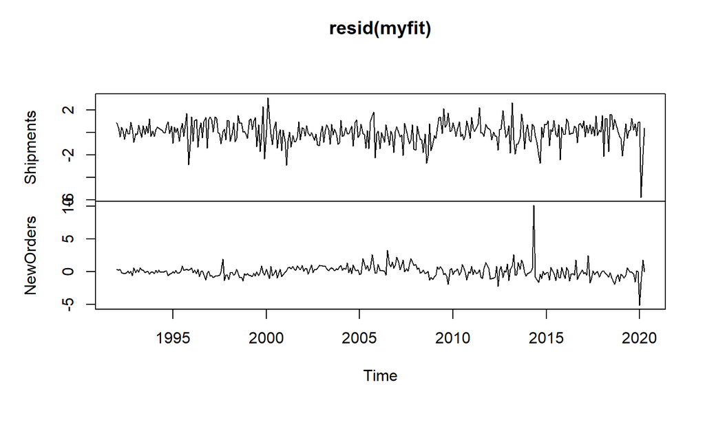

```r
plot(resid(myfit))
```

## Left to be decided

Easy Decisions - What output to display by default for each class -

More Delicate Decisions

- handling matrix vs numeric vector input
  - should work seemlessly for univariate fits
- Decide how to handle AR/MA coefs and matricies for ARMA/VARMA class
  - this is a major source of coding headache
  - currently, almost need to go case by case
    - p > 0, q > 0
    - p > 0, q = 0
    - p = 0 , q > 0